# Risk Factor Analysis

## Outcome Variable

**Outcome Variable:** swasted

## Predictor Variables

**Intervention Variable:** parity

**Adjustment Set:**

- arm
- W_mage
- meducyrs
- feducyrs
- hhwealth_quart
- W_mhtcm
- vagbrth
- W_nrooms
- impsan
- delta_W_mage
- delta_meducyrs
- delta_feducyrs
- delta_hhwealth_quart
- delta_W_mhtcm
- delta_vagbrth
- delta_W_nrooms
- delta_impsan

## Stratifying Variables

The analysis was stratified on these variable(s):

- agecat
- studyid
- country

## Data Summary

| agecat | studyid | country | parity | swasted | n_cell | n |
| --- | --- | --- | --- | --- | --- | --- |
| Birth | ki1000304b-SAS-CompFeed | INDIA | 1 | 0 | 39 | 166 |
| Birth | ki1000304b-SAS-CompFeed | INDIA | 1 | 1 | 2 | 166 |
| Birth | ki1000304b-SAS-CompFeed | INDIA | 2 | 0 | 43 | 166 |
| Birth | ki1000304b-SAS-CompFeed | INDIA | 2 | 1 | 1 | 166 |
| Birth | ki1000304b-SAS-CompFeed | INDIA | 3+ | 0 | 79 | 166 |
| Birth | ki1000304b-SAS-CompFeed | INDIA | 3+ | 1 | 2 | 166 |
| Birth | ki1101329-Keneba | GAMBIA | 1 | 0 | 141 | 1292 |
| Birth | ki1101329-Keneba | GAMBIA | 1 | 1 | 1 | 1292 |
| Birth | ki1101329-Keneba | GAMBIA | 2 | 0 | 133 | 1292 |
| Birth | ki1101329-Keneba | GAMBIA | 2 | 1 | 0 | 1292 |
| Birth | ki1101329-Keneba | GAMBIA | 3+ | 0 | 1008 | 1292 |
| Birth | ki1101329-Keneba | GAMBIA | 3+ | 1 | 9 | 1292 |
| Birth | ki1126311-ZVITAMBO | ZIMBABWE | 1 | 0 | 5154 | 12915 |
| Birth | ki1126311-ZVITAMBO | ZIMBABWE | 1 | 1 | 407 | 12915 |
| Birth | ki1126311-ZVITAMBO | ZIMBABWE | 2 | 0 | 3671 | 12915 |
| Birth | ki1126311-ZVITAMBO | ZIMBABWE | 2 | 1 | 211 | 12915 |
| Birth | ki1126311-ZVITAMBO | ZIMBABWE | 3+ | 0 | 3299 | 12915 |
| Birth | ki1126311-ZVITAMBO | ZIMBABWE | 3+ | 1 | 173 | 12915 |
| Birth | ki1135781-COHORTS | GUATEMALA | 1 | 0 | 84 | 756 |
| Birth | ki1135781-COHORTS | GUATEMALA | 1 | 1 | 10 | 756 |
| Birth | ki1135781-COHORTS | GUATEMALA | 2 | 0 | 109 | 756 |
| Birth | ki1135781-COHORTS | GUATEMALA | 2 | 1 | 9 | 756 |
| Birth | ki1135781-COHORTS | GUATEMALA | 3+ | 0 | 503 | 756 |
| Birth | ki1135781-COHORTS | GUATEMALA | 3+ | 1 | 41 | 756 |
| Birth | ki1135781-COHORTS | INDIA | 1 | 0 | 599 | 3855 |
| Birth | ki1135781-COHORTS | INDIA | 1 | 1 | 42 | 3855 |
| Birth | ki1135781-COHORTS | INDIA | 2 | 0 | 941 | 3855 |
| Birth | ki1135781-COHORTS | INDIA | 2 | 1 | 41 | 3855 |
| Birth | ki1135781-COHORTS | INDIA | 3+ | 0 | 2138 | 3855 |
| Birth | ki1135781-COHORTS | INDIA | 3+ | 1 | 94 | 3855 |

[output cut: 132 more lines]

The following strata were considered:

- agecat: 24 months, studyid: ki1017093b-PROVIDE, country: BANGLADESH
- agecat: 24 months, studyid: ki1066203-TanzaniaChild2, country: TANZANIA, UNITED REPUBLIC OF
- agecat: 24 months, studyid: ki1101329-Keneba, country: GAMBIA
- agecat: 24 months, studyid: ki1113344-GMS-Nepal, country: NEPAL
- agecat: 24 months, studyid: ki1126311-ZVITAMBO, country: ZIMBABWE
- agecat: 24 months, studyid: ki1135781-COHORTS, country: GUATEMALA
- agecat: 24 months, studyid: ki1135781-COHORTS, country: INDIA
- agecat: 24 months, studyid: ki1135781-COHORTS, country: PHILIPPINES
- agecat: 24 months, studyid: kiGH5241-JiVitA-3, country: BANGLADESH
- agecat: 6 months, studyid: ki1000304b-SAS-CompFeed, country: INDIA
- agecat: 6 months, studyid: ki1000304b-SAS-FoodSuppl, country: INDIA
- agecat: 6 months, studyid: ki1017093b-PROVIDE, country: BANGLADESH
- agecat: 6 months, studyid: ki1066203-TanzaniaChild2, country: TANZANIA, UNITED REPUBLIC OF
- agecat: 6 months, studyid: ki1101329-Keneba, country: GAMBIA
- agecat: 6 months, studyid: ki1113344-GMS-Nepal, country: NEPAL
- agecat: 6 months, studyid: ki1126311-ZVITAMBO, country: ZIMBABWE
- agecat: 6 months, studyid: ki1135781-COHORTS, country: GUATEMALA
- agecat: 6 months, studyid: ki1135781-COHORTS, country: INDIA
- agecat: 6 months, studyid: ki1135781-COHORTS, country: PHILIPPINES
- agecat: 6 months, studyid: kiGH5241-JiVitA-3, country: BANGLADESH
- agecat: Birth, studyid: ki1000304b-SAS-CompFeed, country: INDIA
- agecat: Birth, studyid: ki1101329-Keneba, country: GAMBIA
- agecat: Birth, studyid: ki1126311-ZVITAMBO, country: ZIMBABWE
- agecat: Birth, studyid: ki1135781-COHORTS, country: GUATEMALA
- agecat: Birth, studyid: ki1135781-COHORTS, country: INDIA
- agecat: Birth, studyid: ki1135781-COHORTS, country: PHILIPPINES
- agecat: Birth, studyid: kiGH5241-JiVitA-3, country: BANGLADESH

### Dropped Strata

Some strata were dropped due to rare outcomes:

- agecat: Birth, studyid: ki1000304b-SAS-CompFeed, country: INDIA
- agecat: Birth, studyid: ki1101329-Keneba, country: GAMBIA
- agecat: 6 months, studyid: ki1000304b-SAS-FoodSuppl, country: INDIA
- agecat: 6 months, studyid: ki1017093b-PROVIDE, country: BANGLADESH
- agecat: 6 months, studyid: ki1066203-TanzaniaChild2, country: TANZANIA, UNITED REPUBLIC OF
- agecat: 6 months, studyid: ki1101329-Keneba, country: GAMBIA
- agecat: 6 months, studyid: ki1113344-GMS-Nepal, country: NEPAL
- agecat: 6 months, studyid: ki1135781-COHORTS, country: GUATEMALA
- agecat: 6 months, studyid: ki1135781-COHORTS, country: PHILIPPINES
- agecat: 24 months, studyid: ki1017093b-PROVIDE, country: BANGLADESH
- agecat: 24 months, studyid: ki1066203-TanzaniaChild2, country: TANZANIA, UNITED REPUBLIC OF
- agecat: 24 months, studyid: ki1101329-Keneba, country: GAMBIA
- agecat: 24 months, studyid: ki1113344-GMS-Nepal, country: NEPAL
- agecat: 24 months, studyid: ki1135781-COHORTS, country: GUATEMALA
- agecat: 24 months, studyid: ki1135781-COHORTS, country: INDIA
- agecat: 24 months, studyid: ki1135781-COHORTS, country: PHILIPPINES

## Methods Detail

We’re interested in the causal parameters $E[Y_a]$ for all values of $a \in \mathcal{A}$. These parameters represent the mean outcome if, possibly contrary to fact, we intervened to set all units to have $A=a$. Under the randomization and positivity assumptions, these are identified by the statistical parameters $\psi_a=E_W[E_{Y|A,W}(Y|A=a,W)]$. In addition, we’re interested in the mean of $Y$, $E[Y]$ under no intervention (the observed mean). We will estimate these parameters by using SuperLearner to fit the relevant likelihood factors – $E_{Y|A,W}(Y|A=a,W)$ and $p(A=a|W)$, and then updating our likelihood fit using a joint TMLE.

For unadjusted analyses ($W=\{\}$), initial likelihoods were estimated using Lrnr_glm to estimate the simple $E(Y|A)$ and Lrnr_mean to estimate $p(A)$. For adjusted analyses, a small library containing Lrnr_glmnet, Lrnr_xgboost, and Lrnr_mean was used.

Having estimated these parameters, we will then use the delta method to estimate relative risks and attributable risks relative to a prespecified baseline level of $A$.

# Results Detail

## Results Plots

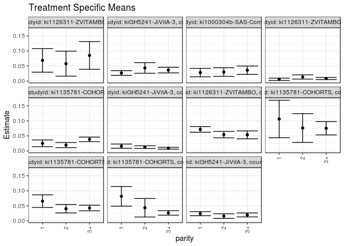

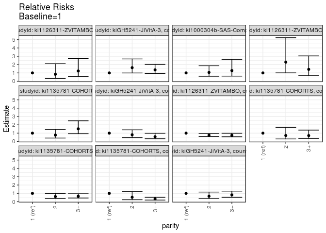

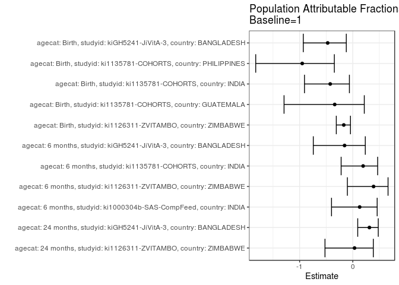

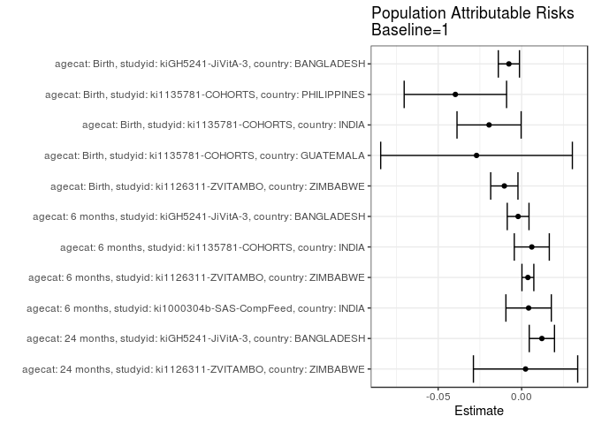

## Results Table

### Parameter: TSM

| agecat | studyid | country | intervention_level | baseline_level | estimate | ci_lower | ci_upper |
| --- | --- | --- | --- | --- | --- | --- | --- |
| Birth | ki1126311-ZVITAMBO | ZIMBABWE | 1 | NA | 0.0716151 | 0.0622246 | 0.0810056 |
| Birth | ki1126311-ZVITAMBO | ZIMBABWE | 2 | NA | 0.0543005 | 0.0436186 | 0.0649824 |
| Birth | ki1126311-ZVITAMBO | ZIMBABWE | 3+ | NA | 0.0535075 | 0.0403871 | 0.0666280 |
| Birth | ki1135781-COHORTS | GUATEMALA | 1 | NA | 0.1063830 | 0.0440119 | 0.1687541 |
| Birth | ki1135781-COHORTS | GUATEMALA | 2 | NA | 0.0762712 | 0.0283479 | 0.1241945 |
| Birth | ki1135781-COHORTS | GUATEMALA | 3+ | NA | 0.0753676 | 0.0531697 | 0.0975656 |
| Birth | ki1135781-COHORTS | INDIA | 1 | NA | 0.0654190 | 0.0444874 | 0.0863507 |
| Birth | ki1135781-COHORTS | INDIA | 2 | NA | 0.0402956 | 0.0262372 | 0.0543541 |
| Birth | ki1135781-COHORTS | INDIA | 3+ | NA | 0.0426191 | 0.0332224 | 0.0520157 |
| Birth | ki1135781-COHORTS | PHILIPPINES | 1 | NA | 0.0814272 | 0.0486340 | 0.1142205 |
| Birth | ki1135781-COHORTS | PHILIPPINES | 2 | NA | 0.0434402 | 0.0126489 | 0.0742315 |
| Birth | ki1135781-COHORTS | PHILIPPINES | 3+ | NA | 0.0262678 | 0.0186947 | 0.0338410 |
| Birth | kiGH5241-JiVitA-3 | BANGLADESH | 1 | NA | 0.0238263 | 0.0171455 | 0.0305071 |
| Birth | kiGH5241-JiVitA-3 | BANGLADESH | 2 | NA | 0.0156349 | 0.0079318 | 0.0233381 |
| Birth | kiGH5241-JiVitA-3 | BANGLADESH | 3+ | NA | 0.0195126 | 0.0128821 | 0.0261431 |
| 6 months | ki1000304b-SAS-CompFeed | INDIA | 1 | NA | 0.0280612 | 0.0140579 | 0.0420646 |
| 6 months | ki1000304b-SAS-CompFeed | INDIA | 2 | NA | 0.0298013 | 0.0154373 | 0.0441654 |
| 6 months | ki1000304b-SAS-CompFeed | INDIA | 3+ | NA | 0.0359375 | 0.0218263 | 0.0500487 |
| 6 months | ki1126311-ZVITAMBO | ZIMBABWE | 1 | NA | 0.0058240 | 0.0021541 | 0.0094939 |
| 6 months | ki1126311-ZVITAMBO | ZIMBABWE | 2 | NA | 0.0133863 | 0.0063105 | 0.0204621 |
| 6 months | ki1126311-ZVITAMBO | ZIMBABWE | 3+ | NA | 0.0083285 | 0.0048677 | 0.0117893 |
| 6 months | ki1135781-COHORTS | INDIA | 1 | NA | 0.0251947 | 0.0139286 | 0.0364608 |
| 6 months | ki1135781-COHORTS | INDIA | 2 | NA | 0.0193646 | 0.0108217 | 0.0279074 |
| 6 months | ki1135781-COHORTS | INDIA | 3+ | NA | 0.0383507 | 0.0307637 | 0.0459378 |
| 6 months | kiGH5241-JiVitA-3 | BANGLADESH | 1 | NA | 0.0157582 | 0.0087496 | 0.0227668 |
| 6 months | kiGH5241-JiVitA-3 | BANGLADESH | 2 | NA | 0.0126517 | 0.0082083 | 0.0170952 |
| 6 months | kiGH5241-JiVitA-3 | BANGLADESH | 3+ | NA | 0.0089367 | 0.0059099 | 0.0119635 |
| 24 months | ki1126311-ZVITAMBO | ZIMBABWE | 1 | NA | 0.0687500 | 0.0294970 | 0.1080030 |
| 24 months | ki1126311-ZVITAMBO | ZIMBABWE | 2 | NA | 0.0578512 | 0.0162040 | 0.0994985 |
| 24 months | ki1126311-ZVITAMBO | ZIMBABWE | 3+ | NA | 0.0851064 | 0.0389937 | 0.1312190 |
| 24 months | kiGH5241-JiVitA-3 | BANGLADESH | 1 | NA | 0.0266324 | 0.0187678 | 0.0344970 |
| 24 months | kiGH5241-JiVitA-3 | BANGLADESH | 2 | NA | 0.0434576 | 0.0259147 | 0.0610005 |
| 24 months | kiGH5241-JiVitA-3 | BANGLADESH | 3+ | NA | 0.0363363 | 0.0270486 | 0.0456239 |

### Parameter: E(Y)

| agecat | studyid | country | intervention_level | baseline_level | estimate | ci_lower | ci_upper |
| --- | --- | --- | --- | --- | --- | --- | --- |
| Birth | ki1126311-ZVITAMBO | ZIMBABWE | NA | NA | 0.0612466 | 0.0571111 | 0.0653822 |
| Birth | ki1135781-COHORTS | GUATEMALA | NA | NA | 0.0793651 | 0.0600839 | 0.0986462 |
| Birth | ki1135781-COHORTS | INDIA | NA | NA | 0.0459144 | 0.0393065 | 0.0525222 |
| Birth | ki1135781-COHORTS | PHILIPPINES | NA | NA | 0.0417385 | 0.0344572 | 0.0490198 |
| Birth | kiGH5241-JiVitA-3 | BANGLADESH | NA | NA | 0.0161866 | 0.0138216 | 0.0185515 |
| 6 months | ki1000304b-SAS-CompFeed | INDIA | NA | NA | 0.0322339 | 0.0235219 | 0.0409459 |
| 6 months | ki1126311-ZVITAMBO | ZIMBABWE | NA | NA | 0.0095607 | 0.0074624 | 0.0116590 |
| 6 months | ki1135781-COHORTS | INDIA | NA | NA | 0.0312719 | 0.0260599 | 0.0364838 |
| 6 months | kiGH5241-JiVitA-3 | BANGLADESH | NA | NA | 0.0136505 | 0.0115778 | 0.0157231 |
| 24 months | ki1126311-ZVITAMBO | ZIMBABWE | NA | NA | 0.0710900 | 0.0465431 | 0.0956370 |
| 24 months | kiGH5241-JiVitA-3 | BANGLADESH | NA | NA | 0.0387435 | 0.0344172 | 0.0430697 |

### Parameter: RR

| agecat | studyid | country | intervention_level | baseline_level | estimate | ci_lower | ci_upper |
| --- | --- | --- | --- | --- | --- | --- | --- |
| Birth | ki1126311-ZVITAMBO | ZIMBABWE | 1 | 1 | 1.0000000 | 1.0000000 | 1.0000000 |
| Birth | ki1126311-ZVITAMBO | ZIMBABWE | 2 | 1 | 0.7582269 | 0.5985877 | 0.9604410 |
| Birth | ki1126311-ZVITAMBO | ZIMBABWE | 3+ | 1 | 0.7471542 | 0.5657717 | 0.9866867 |
| Birth | ki1135781-COHORTS | GUATEMALA | 1 | 1 | 1.0000000 | 1.0000000 | 1.0000000 |
| Birth | ki1135781-COHORTS | GUATEMALA | 2 | 1 | 0.7169492 | 0.3035745 | 1.6932122 |
| Birth | ki1135781-COHORTS | GUATEMALA | 3+ | 1 | 0.7084559 | 0.3675932 | 1.3653943 |
| Birth | ki1135781-COHORTS | INDIA | 1 | 1 | 1.0000000 | 1.0000000 | 1.0000000 |
| Birth | ki1135781-COHORTS | INDIA | 2 | 1 | 0.6159622 | 0.3837068 | 0.9888006 |
| Birth | ki1135781-COHORTS | INDIA | 3+ | 1 | 0.6514781 | 0.4417716 | 0.9607311 |
| Birth | ki1135781-COHORTS | PHILIPPINES | 1 | 1 | 1.0000000 | 1.0000000 | 1.0000000 |
| Birth | ki1135781-COHORTS | PHILIPPINES | 2 | 1 | 0.5334850 | 0.2361071 | 1.2054118 |
| Birth | ki1135781-COHORTS | PHILIPPINES | 3+ | 1 | 0.3225928 | 0.1966062 | 0.5293127 |
| Birth | kiGH5241-JiVitA-3 | BANGLADESH | 1 | 1 | 1.0000000 | 1.0000000 | 1.0000000 |
| Birth | kiGH5241-JiVitA-3 | BANGLADESH | 2 | 1 | 0.6562056 | 0.3714375 | 1.1592955 |
| Birth | kiGH5241-JiVitA-3 | BANGLADESH | 3+ | 1 | 0.8189543 | 0.5272619 | 1.2720173 |
| 6 months | ki1000304b-SAS-CompFeed | INDIA | 1 | 1 | 1.0000000 | 1.0000000 | 1.0000000 |
| 6 months | ki1000304b-SAS-CompFeed | INDIA | 2 | 1 | 1.0620108 | 0.6052683 | 1.8634168 |
| 6 months | ki1000304b-SAS-CompFeed | INDIA | 3+ | 1 | 1.2806818 | 0.6228782 | 2.6331726 |
| 6 months | ki1126311-ZVITAMBO | ZIMBABWE | 1 | 1 | 1.0000000 | 1.0000000 | 1.0000000 |
| 6 months | ki1126311-ZVITAMBO | ZIMBABWE | 2 | 1 | 2.2984544 | 1.0098248 | 5.2314943 |
| 6 months | ki1126311-ZVITAMBO | ZIMBABWE | 3+ | 1 | 1.4300189 | 0.6722211 | 3.0420854 |
| 6 months | ki1135781-COHORTS | INDIA | 1 | 1 | 1.0000000 | 1.0000000 | 1.0000000 |
| 6 months | ki1135781-COHORTS | INDIA | 2 | 1 | 0.7685974 | 0.4100998 | 1.4404836 |
| 6 months | ki1135781-COHORTS | INDIA | 3+ | 1 | 1.5221751 | 0.9335491 | 2.4819447 |
| 6 months | kiGH5241-JiVitA-3 | BANGLADESH | 1 | 1 | 1.0000000 | 1.0000000 | 1.0000000 |
| 6 months | kiGH5241-JiVitA-3 | BANGLADESH | 2 | 1 | 0.8028668 | 0.4602159 | 1.4006364 |
| 6 months | kiGH5241-JiVitA-3 | BANGLADESH | 3+ | 1 | 0.5671110 | 0.3263008 | 0.9856392 |
| 24 months | ki1126311-ZVITAMBO | ZIMBABWE | 1 | 1 | 1.0000000 | 1.0000000 | 1.0000000 |
| 24 months | ki1126311-ZVITAMBO | ZIMBABWE | 2 | 1 | 0.8414726 | 0.3357357 | 2.1090285 |
| 24 months | ki1126311-ZVITAMBO | ZIMBABWE | 3+ | 1 | 1.2379110 | 0.5634392 | 2.7197677 |
| 24 months | kiGH5241-JiVitA-3 | BANGLADESH | 1 | 1 | 1.0000000 | 1.0000000 | 1.0000000 |
| 24 months | kiGH5241-JiVitA-3 | BANGLADESH | 2 | 1 | 1.6317543 | 0.9939422 | 2.6788500 |
| 24 months | kiGH5241-JiVitA-3 | BANGLADESH | 3+ | 1 | 1.3643622 | 0.9177950 | 2.0282134 |

### Parameter: PAR

| agecat | studyid | country | intervention_level | baseline_level | estimate | ci_lower | ci_upper |
| --- | --- | --- | --- | --- | --- | --- | --- |
| Birth | ki1126311-ZVITAMBO | ZIMBABWE | 1 | NA | -0.0103685 | -0.0185275 | -0.0022094 |
| Birth | ki1135781-COHORTS | GUATEMALA | 1 | NA | -0.0270179 | -0.0844158 | 0.0303800 |
| Birth | ki1135781-COHORTS | INDIA | 1 | NA | -0.0195046 | -0.0387080 | -0.0003013 |
| Birth | ki1135781-COHORTS | PHILIPPINES | 1 | NA | -0.0396887 | -0.0703530 | -0.0090244 |
| Birth | kiGH5241-JiVitA-3 | BANGLADESH | 1 | NA | -0.0076397 | -0.0139716 | -0.0013078 |
| 6 months | ki1000304b-SAS-CompFeed | INDIA | 1 | NA | 0.0041727 | -0.0094235 | 0.0177689 |
| 6 months | ki1126311-ZVITAMBO | ZIMBABWE | 1 | NA | 0.0037366 | 0.0001829 | 0.0072904 |
| 6 months | ki1135781-COHORTS | INDIA | 1 | NA | 0.0060772 | -0.0044060 | 0.0165605 |
| 6 months | kiGH5241-JiVitA-3 | BANGLADESH | 1 | NA | -0.0021078 | -0.0086200 | 0.0044044 |
| 24 months | ki1126311-ZVITAMBO | ZIMBABWE | 1 | NA | 0.0023400 | -0.0288845 | 0.0335646 |
| 24 months | kiGH5241-JiVitA-3 | BANGLADESH | 1 | NA | 0.0121110 | 0.0045532 | 0.0196688 |

### Parameter: PAF

| agecat | studyid | country | intervention_level | baseline_level | estimate | ci_lower | ci_upper |
| --- | --- | --- | --- | --- | --- | --- | --- |
| Birth | ki1126311-ZVITAMBO | ZIMBABWE | 1 | NA | -0.1692908 | -0.3100859 | -0.0436270 |
| Birth | ki1135781-COHORTS | GUATEMALA | 1 | NA | -0.3404255 | -1.2928794 | 0.2163824 |
| Birth | ki1135781-COHORTS | INDIA | 1 | NA | -0.4248042 | -0.9085941 | -0.0636452 |
| Birth | ki1135781-COHORTS | PHILIPPINES | 1 | NA | -0.9508889 | -1.8258021 | -0.3468628 |
| Birth | kiGH5241-JiVitA-3 | BANGLADESH | 1 | NA | -0.4719761 | -0.9310665 | -0.1220295 |
| 6 months | ki1000304b-SAS-CompFeed | INDIA | 1 | NA | 0.1294495 | -0.4000328 | 0.4586853 |
| 6 months | ki1126311-ZVITAMBO | ZIMBABWE | 1 | NA | 0.3908339 | -0.1017098 | 0.6631751 |
| 6 months | ki1135781-COHORTS | INDIA | 1 | NA | 0.1943344 | -0.2192206 | 0.4676131 |
| 6 months | kiGH5241-JiVitA-3 | BANGLADESH | 1 | NA | -0.1544098 | -0.7428586 | 0.2353585 |
| 24 months | ki1126311-ZVITAMBO | ZIMBABWE | 1 | NA | 0.0329167 | -0.5228379 | 0.3858505 |
| 24 months | kiGH5241-JiVitA-3 | BANGLADESH | 1 | NA | 0.3125956 | 0.0928415 | 0.4791155 |